# Network Analysis

Liudmyla Kotusenko (11258622), Yuchen Wang (11273123)

March 2020

# 1. Introduction

In the past century, networks have surged in popularity and have become universal in our society: from virtual networks like the World Wide Web (web-pages connected by hyperlinks) and the Internet (routers linked by various physical lines) to physical networks such as transportation networks, supply chain networks (brings groceries to your nearest supermarket) as well as networks of neurons in the brain(Franceschet 2020). The recent explosion in social media also gave rise to social networks which have become integral to everyone’s daily lives.

Network analysis is a set of techniques that aim to learn and extract insights from networks. It is often employed to deal with large and complex networks that require special algorithms and techniques. The field of network analysis is vast and it could easily take an entire course to gain merely a basic understanding of network analytics (for example, Gilles Caporossi gives a whole course on Complex Networks Analysis at HEC Montreal).

In this paper, we will only scrape the surface of network analysis and focus on several elementary but nevertheless important applications of network analytics. We will first show how to generate networks from a simple dataset in R, how to create basic but powerful visualizations and calculate some basic graph properties. Given its importance and ubiquity, we will also briefly discuss community detection.

As the best way to learn anything is by doing it, we will explore the above-mentioned aspects of network analysis by analyzing a narrative network of relations between characters in fiction novels. The techniques explored are however applicable to all types of networks. The dataset that we’ll be working with is generated based on the bestselling book series *A Song of Ice and Fire* by George R.R. Martin. The relationships between characters are generated based on the proximity of the position of character names in the text, an edge (connection) is created every time two character names appear less than 15 words apart.

# 2. Literature review

Network analysis is rooted in graph theory, a very old and well-established branch of mathematics. The field of graph theory began with Euler’s solution to the problem of the Seven Bridges of Königsberg and has been developed extensively due to its usefulness in organic chemistry, electrical engineering and biology. As a result, resources for network analysis are abundant, ranging from textbooks to online open access lecture slides. We have selected a few that were particularly useful and relevant to our study.

In the online lecture slide, Ghoshdastidar (2019) presents an introductory course of network analysis and explains basic network properties and measures. The course also explains more complex models and theorems that are outside the scope of this paper and will not be discussed.

Hevey (2018) presents an overview of applied network analysis in psychology. The paper explores the uses of networks and provides simpler explanations of network measures as well as examples in psychology. This paper also provides an example of how to perform network analysis in R using data on the Theory of Planned Behaviour.

With recent developments in social network analysis, the topic of community detection has surged in popularity. Fortunato (2009) discusses recent advancements and evolution in the problem of community detection and presents some common approaches such as graph partitioning, hierarchical clustering and spectral clustering.

Despite recent developments, the problem of community detection remains vague and elusive. In their 2016 paper, Fortunato and Hric explain in detail why community detection remains difficult: from disagreements in its very definition to non-existent group structures naturally arising out of random graphs.

With regards to implementations of network analysis in R, Luke (2015) provides a comprehensive user’s guide to network analytics in R. The book covers wrangling network data in R, its visualization, description and analysis along with network modeling and simulation. The examples of R use are abundant and cover two major R packages such as `statnet` and `igraph`, among others.

Samatova et al also give a useful guide with their work Nagiza F. Samatova (2014). The 2014 book, albeit more mathematical in nature, explains in detail the proximity measures as well as the algorithms implemented in the R libraries for community detection and clustering.

# 3. Brief description of the methods

Networks are commonly represented as graphs - mathematical structures describing pairwise relations between objects. As such, networks are defined as objects of graph theory (Wikipedia 2020). Each network contains **nodes** (e.g. people in a social network, cities in a flight network of a given air company), which are called **vertices** in the graph theory, and **connections** or **ties** between them, also known as **edges**, **arcs** or **links**.

A Network can also be represented as an **adjacency matrix** (aka a **sociomatrix** in social networks analysis). It is a square matrix with node names in both rows and columns with cells specifying whether the connection between two nodes exists (1) or not (0). Alternatively, instead of 0-1 values, adjacency matrix cells can contain edge weights. The adjacency matrix is symmetric/non-symmetric for undirected/directed networks, respectively.

Before describing the network analysis methods, it is crucial to first define some basic notations and explain some fundamental concepts used in graph theory:

A graph is defined as:
$$G = (V,E)$$

- where $V$ is the set of *nodes* or *vertices* (e.g. people in a social network, cities in a flight network of a given air company)
- and $E$ is the set of *edges* or *links*

Depending on the connections between the nodes, networks can be classified as either **directed** or **undirected**. An **undirected** network has reciprocal connections between nodes (like friends in a social network or two-way roads in the city), whilst a directed one has connections going in one direction only, from a source node to the target one (e.g., followers on social media, a coronavirus spread network, a water supply network or a network of Bixi trips).

Nodes or edges in the network can have labels. For example, for clients of a given company, node labels can contain not only the name of a client but also their sex, age, whether a client is a churner or not etc. (DataCamp 2020).

Networks can be weighted, i.e., each node and/or edge can have a weight (or several weights) assigned to it. For example, in a supply chain network, edges can have weights representing distances between nodes (warehouses), while node weights could describe each warehouse capacity (Caporossi and Camby 2017).

There also exist many special network structure definitions such as bipartite networks, where the nodes can be split into two disjoint and independent sets and every edge connects two nodes from the two sets. One example would be Amazon clients (one set of nodes) rating products (another set of nodes). These networks are however not the focus of this paper and will not be discussed in detail.

We will be focusing on analysis done on an undirected network for the sake of simplicity, but all of our methods can be generalised to directed networks with minimal alteration. Due to the limited scope of this paper, in the network analysis part, we will concentrate on:

- creating a network and exploring its basic properties and statistics, along with network centrality measures;
- network visualization;
- community detection.

## Network generation and description

We’ll begin by generating a graph from the dataset and explore some basic descriptive statistics for networks such as size, degree, centrality, etc.

$$Density = \frac{2|E|}{|V|(|V|-1)}$$

- A measure similar to *density*, **transitivity** is another important measure in social networks. It is defined as the ratio of transitive triads (sub-graphs of 3 nodes that are interconnected) over the total number of possible transitive triads that can be formed in a graph with $V$ nodes.
- The **distance** or **graph geodesic**, $d(v_i,v_j)$ between two nodes $v_i$ and $v_j$ of the graph is the shortest path that connects the two nodes together.
- The **Diameter** of a network is defined as the longest geodesic between two nodes in the network. In more technical terms, given the set $S(d)$ of geodesics between all pairs of nodes $<v_i,v_j>$ it is defined as $max\{S\}$. The diameter represents the linear size of the network.
- **Node degree**: the degree of a node in the network is the number of edges connected to the node. In directed graphs we can have *in-degree* (number of inward edges) and *our-degree* (number of outward edges). Given the adjacency matrix A of an undirected graph, we have:

$$deg(v_i) = \sum_j a_{ij}$$

- **Centrality**, commonly denoted as $C$, is a measure of prominence (importance) of nodes in undirected graphs. In directed graphs it is known as **prestige**. Many centrality measures exist, we will discuss a few common ones in this paper.

  - *Degree centrality*: based on the simple notion that more connected nodes are more prominent than less connected ones, *degree centrality* is quite straightforwardly the degree of nodes.

$$C_d(v_i) = deg(v_i)$$

- *Closeness centrality*: a step further would be to include indirect connections in the analysis. *Closeness centrality* measures the average length of the shortest path between the current node and all other nodes. The prominent nodes are the ones closest to other nodes in the network.

$$C_c(v_i) = \frac{1}{\sum_{v_j} d(v_i,v_j) }$$

- *Harmonic centrality* is a variant of closeness centrality that deals with unconnected graphs.

$$C_h(v_i) = \sum_{v_j \neq v_i} \frac{1}{d(v_i,v_j)}$$

- *Betweenness centrality* measures the number of times a node acts as an intermediary for the shortest path between two other nodes. Given $d_{v_jv_k}$, the geodesic of two nodes $v_j$ and $v_k$, and $d_{v_jv_k}(v_i)$, the geodesic of two nodes $v_j$ and $v_k$ passing through $v_i$, the betweenness centrality is defined as:

$$C_b(v_i) = \sum_{v_i \neq v_j \neq v_k} \frac{d_{v_jv_k}(v_i)}{d_{v_jv_k} }$$

- *Eigencentrality* measures the influence of a node in the network. It provides a measure of importance taking into account the importance of its adjacent nodes. Given the adjacency matrix A of an undirected graph, we can calculate the eigencentrality by finding the eigenvector $\mathbf{x}$ of the adjacency matrix:

$$\mathbf{Ax} = \lambda \mathbf{x}$$

## Community detection (clusters)

In networks, a commonly encountered structure is that some nodes are better connected to each other than to the rest of the network, i.e. the nodes are grouped together. This type of network is said to have community structure and the groups are called communities.

Unfortunately, there is no universally accepted definition of community. The broad definition is that there must be more *edges* within the community than with other communities, but different packages in R implement different definitions depending on their field of application. In addition, there exist many algorithms for community detection and each algorithm is suited to a different field of research. It is impossible to be exhaustive in our example and demonstrate all algorithms available, so we will explore only those from the `igraph` package and select that which yields useful insights in our example.

## Network visualizations

We will present methods for visualising graphs to highlight certain graph characteristics. As plotting even a moderately sized network is not a trivial task, we will explore the main principles of network plotting and briefly discuss network plot layouts. Then we will plot our network highlighting different centrality measures, such as node degree and edge weight in one case, and node and edge betweenness in another. We will also plot communities detected by the best performing algorithm. On top of that, we will make several interactive network plots.

# 4. Resources available in R

There are many packages in R designed to implement network analysis and even more packages that include basic network description and analysis in their functionality. Despite the fact that many packages offer functions that are similar in nature, we have decided to discuss all relevant packages relating to network analysis in the interest of exhaustiveness. Unless otherwise specified, all packages are from the *CRAN* repository.

Two broad frameworks exist in R for the creation and manipulation of networks, the `statnet` package collection and `igraph`. Networks are stored and manipulated as **network** objects in the `statnet` framework and as **igraph** objects in `igraph`. Although it is technically possible to interchange between the two frameworks, it is discouraged as functions in both libraries have naming conflicts and would cause unnecessary complications.

`Statnet` is a collection of packages in network analysis commonly used by statisticians and social scientists such as `network`, `sna`(social network analysis) and `ergm`(exponential-family random graph models). This `statnet` package collection is more comprehensive than `igraph` in the variety of statistical tools offered, but its algorithms are less time-efficient and deal poorly with large datasets. Installing and loading the `statnet` will automatically load all the packages mentioned below (this list is not exhaustive but mentions the main packages).

- The package `network` and `networkDynamic` (an extension of `network` that allows for the handling temporal data) are packages belonging to the `Statnet` project that includes many tools for the creation, description and manipulation of **network** objects. A **network** object can be created by applying the function *as.network()* to adjacency matrices or edge lists. Once a **network** object has been created, the package offers functions that can implement basic manipulations such as adding nodes and edges or transforming the structure to an adjacency matrix or edge list. Basic descriptive statistics such as *density* are also offered.
- `sna` and its temporal counterpart `tsna` expands the package by offering functions that implement more advanced statistics like the various centrality measures. The package also offers tools more specifically tailored towards social network analysis, such as structural equivalence detection and network regression. The package also offers network visualizations with `gplot()` function that allows for better customization than generic `plot()` function available in `statnet` suite.
- `ergm` and its derivatives (e.g: `ergm.count` and `ergm.ego`) are packages that offer tools to analyze, fit and generate a special type of graphs, the exponential-family random graph models. ERGMS are statistical models and once fitted, these models can be used to conduct statistical inference or prediction on graphical datasets. The popularity of these random network modes have surged recently and have had a substantial impact on social network analysis.

The package `igraph` is another package that offers network analysis and visualization tools in R. Its strength lies in its ability to handle large networks as it is more computationally efficient than the `statnet` suite and offers built-in algorithms for community detection. It has gained in popularity in recent years and its capabilities have been extended by other packages that can work with the **igraph** network object that it generates. Among the most useful are `tidygraph` and `ggraph`, packages built by Thomas Lin Pedersen that “leverage the power of igraph in a manner consistent with the tidyverse workflow”. (Sadler 2017)

- The `igraph` package was developed in parallel with the statnet project and has established itself solidly in the R community due to its ability to efficiently handle very large graphs. In `igraph`, networks are stored as *igraph* objects and can be created from data frames of edges using the function *graph_from_data_frame()*. Once created, the *igraph* objects can be manipulated and described much like in the `statnet` packages.
- `igraphdata` is simply a collection of network datasets that has been formatted to work well with the `igraph` package. It includes many famous benchmark datasets like the Enron email network and the karate club network.

In addition to the two main frameworks, other less popular packages exist that offer similar functions. The package `graph` hosted on the Bioconductor repository provides tools for simple network handling. Compared to `statnet` and `igraph`, `graph` offers significantly fewer functionalities but is nevertheless a viable package that implements most of the basic tools used in network analysis.

Furthermore, a wide range of specialised packages also exist that serve specific purposes such as graph visualisation and manipulation:

- Inspired by the `tidyverse` suite, `tidygraph` provides tools that implement functions capable of manipulating networks in a way that conforms to the “tidy” philosophy. While it is originally designed to work with *igraph* objects, `tidygraph` has since been updated to work on *tbl_graph* objects to which most network object structures can be converted.
- `ggraph` was motivated by the poor fit of the `ggplot2` package on graphs. It expands on `ggplot2` and offers implementations of graphical visualisation methods for networks. Like `ggraph`, `tidygraph` also works with *tbl_graph* objects. It is one of the most comprehensive packages for network graphics.
- `ggnet2` is a function for plotting networks in the `GGally` suite, a collection of packages that extends `ggplot2`. While the visualisation tools provided by `ggnet2` can only be applied on objects of type **network**, the package offers the `asNetwork` function that can coerce **igraph** objects into **network**.
- The package `ggnetwork` is yet another package that implements visualisation tools for networks. It supports equally well **network** and **igraph** objects.

Interactive visualisations of networks can also be implemented with the packages `visNetwork`, `networkD3`, `sigmajs` and `threejs` that make use of javascript. These packages make use of different javascript libraries and deliver slightly different results. For example, `visNetwork` and `networkD3` allow a user to zoom in/out and drag nodes around, while `threejs` allows rotations.

It is often difficult for novice data scientists to explore new packages via the CRAN manuals. The overwhelming number of functions inside each package manual is enough to discourage even those that are the most enthousiastic. As such, we provide below a collection of guides that give quick introductions to some of the aforementioned packages:

Sadler (2017) gives a gentle introduction to creating and plotting network objects first with packages **network** and **igraph** and later introduces network wrangling in a “tidy” way, using packages **tidyverse** and **tidygraph**. **ggraph**, **visNetwork** and **networkD3** package functionalities are used to visualize networks.

DataCamp offers several courses on network analytics in R and Python. A track “Network Analysis with R” includes the following courses (DataCamp 2020):

- *Network Analysis in R* covers creating networks from edge lists and adjacency matrices, plotting networks and their attributes, identifying important vertices and special relationships between vertices, and creating interactive network plots.
- *Predictive Analytics using Networked Data in R* uses network analytics “to predict to which class a network node belongs, such as churner or not, fraudster or not, defaulter or not, etc.”
- *Network Analysis in the Tidyverse* shows how network analysis can be done in a tidy way, using R packages such as dplyr, ggplot2, igraph, ggraph and visNetwork.
- *Case Studies: Network Analysis in R* uses Amazon purchase data, Twitter mentions of R and bike-sharing data to demonstrate powers and challenges of network analysis on big real-world data sets.

In the subsequent part, we will focus mainly on the `igraph` package for network analysis and `ggraph` and `visNetwork` packages for visualization. As interactive visualization is supported in *html* format only, we provide this document in *pdf* and *html* formats.

# 5. Data analysis example

In this chapter, we provide an example of network analysis. The dataset that we’ll be working with is generated based on the bestselling book series by George R.R. Martin, *A Song of Ice and Fire*.This dataset can be found on Kaggle (https://www.kaggle.com/mmmarchetti/game-of-thrones-dataset), though it is believed that the original data source is here: https://github.com/mathbeveridge/asoiaf.

The dataset contains co-occurrences of pairs of characters in the books (connections). Two characters are considered to co-occur if their names appear in the vicinity of 15 words from one another. The number of times each pair of characters appears together in the text is captured in the *weight* field. There is a separate file for each book (1-5). To simplify our analysis, we will be using only the dataset based on the first book of the series, *A Game of Thrones*, to which we will refer as the *GoT dataset*.

## 5.1 Reading in and preprocessing data

First, we load all the necessary packages.

```r
library(igraph)
library(ggplot2)
library(RColorBrewer)
library(ggraph)
library(visNetwork)
library(tidygraph)
library(tidyverse)
library(dplyr)
library(corrplot)
```

Next, we read in the data and quickly explore it.

```r
book1 = read.csv("book1.csv")
nrow(book1) # show the number of rows in the dataset
```

```
## [1] 684
```

```r
summary(book1)
```

```
##                Source                 Target            Type
##  Eddard-Stark     : 51   Robert-Baratheon: 41   Undirected:684
##  Catelyn-Stark    : 39   Tyrion-Lannister: 41
##  Bran-Stark       : 30   Sansa-Stark     : 31
##  Arya-Stark       : 27   Robb-Stark      : 22
##  Cersei-Lannister : 23   Jon-Snow        : 20
##  Joffrey-Baratheon: 19   Tywin-Lannister : 20
##  (Other)          :495   (Other)         :509
##      weight            book
##  Min.   :  3.00   Min.   :1
##  1st Qu.:  4.00   1st Qu.:1
##  Median :  5.00   Median :1
##  Mean   : 10.77   Mean   :1
##  3rd Qu.: 11.00   3rd Qu.:1
##  Max.   :291.00   Max.   :1
##
```

```r
head(book1,3) # show top-3 lines from the dataset
```

|  | Source | Target | Type | weight | book |
| --- | --- | --- | --- | --- | --- |
| 1 | Addam-Marbrand | Jaime-Lannister | Undirected | 3 | 1 |
| 2 | Addam-Marbrand | Tywin-Lannister | Undirected | 6 | 1 |
| 3 | Aegon-I-Targaryen | Daenerys-Targaryen | Undirected | 5 | 1 |

Our dataframe contains 684 lines, or pairs of characters appearing together in the book 1, with the “weight” column specifying how many times a given pair co-occurred. Columns “Source” and “Target” show connected pairs of characters. Column “Type” mentions “undirected” everywhere: there is no direction in connections between characters. We can remove columns “Type” and “book” since they are of no use to us. Also, we replace hyphens in the character names with spaces, using the `gsub()` command for it.

```r
book1 = book1[,c(1:2,4)]
book1$Source = gsub("-"," ", book1$Source)
book1$Target = gsub("-"," ", book1$Target)
head(book1,3)
```

|  | Source | Target | weight |
| --- | --- | --- | --- |
| 1 | Addam Marbrand | Jaime Lannister | 3 |
| 2 | Addam Marbrand | Tywin Lannister | 6 |
| 3 | Aegon I Targaryen | Daenerys Targaryen | 5 |

## 5.2 Creating a network and exploring its basic statistics

The next step would be to create a network from this data. There exist several ways to do it: one approach is to create a list of nodes and a list of edges which we can then combine in a network object; another is to represent the network as an **adjacency matrix**.

Adjacency matrices can become overly large and sparse very quickly which complicates their handling. The former approach is thus a more practical one since all major network analysis packages in R allow creating of a network object from vertex and edge lists. The following commands, shown in a form of `package_name::function_name()` pairs, will do this for us:

- `network::network()` (from `statnet` suite of packages)
- `igraph::graph_from_data_frame()`
- `tidygraph::tbl_graph()`

In fact, `network::network()` and `igraph::graph_from_data_frame()` allow us to create a network object right from a dataframe of edges. The latter requires the first two columns to provide pairs of connected nodes. Any other columns are considered as edge attributes.

However, Sadler (2017) warns that *“The network object classes for network, igraph, and tidygraph are all closely related. It is possible to translate between a network object and an igraph object. However, it is best to keep the two packages and their objects separate. In fact, the capabilities of network and igraph overlap to such an extent that it is best practice to have only one of the packages loaded at a time”*.

Given the limitations of this paper, we will focus on the use of `igraph` package to carry out network analysis since it has implemented comprehensive community detection techniques and will also allow us to produce clear plots with the use of `ggraph` package.

As our dataframe already provides the pairs of connected nodes in the first two columns, we can simply use the `graph_from_data_frame()` command to create a network right away. Once we have created our network object, we can use the `summary()` function to explore it.

```r
GoT = graph_from_data_frame(d = book1, directed = FALSE)
summary(GoT)
```

```
## IGRAPH 097aa65 UNW- 187 684 --
## + attr: name (v/c), weight (e/n)
```

The first line of the summary contains the main information about our graph object. **UNW-** stands for undirected network (**U**) with a name attribute (**N**) and weighted edges (**W**) and which is not bipartite (**-**). This is followed by the number of nodes (187) and edges (684) in the graph (**size** of our network). The second line shows the attributes of the network: **name (v/c), weight (e/n)**. The first attribute refers to vertices and the second to edges which are shown by letters **v** and **e** in parentheses, respectively (Sadler 2017). **/c** and **/n** show the type of our attributes: **character** and **numeric**, respectively.

Functions `V(graph)` and `E(graph)` extract vertices and edges from an `igraph` network, respectively, and can be useful when we need to provide a function with either of them or add/extract a node/edge attribute.

```r
head(V(GoT))
```

```
## + 6/187 vertices, named, from 097aa65:
## [1] Addam Marbrand                  Aegon I Targaryen
## [3] Aemon Targaryen (Maester Aemon) Aerys II Targaryen
## [5] Aggo                            Albett
```

```r
head(E(GoT),3)
```

```
## + 3/684 edges from 097aa65 (vertex names):
## [1] Addam Marbrand   --Jaime Lannister    Addam Marbrand   --Tywin Lannister
## [3] Aegon I Targaryen--Daenerys Targaryen
```

We already saw the size of the GoT network while interpreting its summary. Another way to get **size** of a network is to count node and tie numbers with the following functions:

```r
vcount(GoT) # get the number of nodes
```

```
## [1] 187
```

```r
ecount(GoT) # get the number of ties
```

```
## [1] 684
```

Let’s now look at main network statistics. While it’s nice to know the total number of connections in our network, it does not tell us much about network interconnectedness. Instead, **network density** does, since it directly demonstrates the share of actual ties in a network among the maximum possible number of ties for this network. Network density takes values from 0 to 1. It appears that the density of the GoT network is quite low.

```r
edge_density(GoT)
```

```
## [1] 0.03933069
```

```r
transitivity(GoT, type = "global") # removing type = "global" yields the same result
```

```
## [1] 0.3302343
```

```r
head(transitivity(GoT, type = "local")) # transitivity for the first 6 people
```

```
## [1] 1.0000000 1.0000000 0.5714286 0.6666667 0.7333333 1.0000000
```

```r
head(count_triangles(GoT)) # number of triangles for the first 6 people
```

```
## [1]  1  1 12 10 11  3
```

Another important measure of a network is **diameter**, the maximum shortest path between the nodes in a network (Ghoshdastidar 2019). In an unweighted network, it measures the maximum number of hops that separate one node from another and as such is a measure of the compactness of a network. According to Luke (2015), “the diameter reﬂects the ‘worst-case scenario’ for sending information (or any other resource) across a network.” The diameter is undeﬁned for networks that contain two or more components (parts that have no connections between them). In this case, it is usually best to examine the diameter of the largest component in the network.

If a network is weighted, by default, the call of `diameter()` will account for weights, but the result will be hard to interpret. We specify `weights = NA` in it to get a more intuitive result: we require 7 hops to go between the farthest nodes in a network. We can also explore the longest shortest path by calling `get_diameter()` function. `farthest_vertices()` will output the pair of nodes with the highest distance between them as well as the distance itself.

```r
diameter(GoT, weights = NA) # disable weights
```

```
## [1] 7
```

```r
get_diameter(GoT, weights = NA) # explore the longest path between two nodes
```

```
## + 8/187 vertices, named, from 097aa65:
## [1] Clement Piper    Karyl Vance      Edmure Tully     Catelyn Stark
## [5] Robert Baratheon Drogo            Ogo              Fogo
```

```r
farthest_vertices(GoT, weights = NA)
```

```
## $vertices
## + 2/187 vertices, named, from 097aa65:
## [1] Clement Piper Fogo
##
## $distance
## [1] 7
```

We can also calculate **degree** of each node, i.e. the number of nodes it is connected to. Since our network is non-directed, we’ll have a single degree measure per node instead of two: **in-degree** and **out-degree**, as is the case in directed networks. The degree of each node in the network is calculated and the top-10 most connected characters are shown below :

```r
deg = degree(GoT) # produces a named vector of degrees
head(sort(deg, decreasing = TRUE), 10) # top-10 characters by degree
```

```
##      Eddard Stark  Robert Baratheon  Tyrion Lannister     Catelyn Stark
##                66                50                46                43
##          Jon Snow        Robb Stark       Sansa Stark        Bran Stark
##                37                35                35                32
##  Cersei Lannister Joffrey Baratheon
##                30                30
```

It is possible to save *degree* as a vertex attribute for later use. To add/extract an attribute from a vertex/edge list, we use the command `V(graph)$attribute` or `E(graph)$attribute`. However, if we were given a network with attributes and needed to explore them, getting a list of top-10 most prominent characters would be more tricky than what we did above. We use the `order()` function to sort our degree vector in descending order, take top-10 values from it and apply this sequence to filter our vertices.

```r
V(GoT)$degree = degree(GoT)
V(GoT)[head(order(V(GoT)$degree, decreasing = TRUE),10)] # top-10 characters by degree
```

```
## + 10/187 vertices, named, from 097aa65:
##  [1] Eddard Stark      Robert Baratheon  Tyrion Lannister  Catelyn Stark
##  [5] Jon Snow          Robb Stark        Sansa Stark       Bran Stark
##  [9] Cersei Lannister  Joffrey Baratheon
```

We can use the same commands to see what pairs of characters have the strongest connections (the largest weights associated with their ties).

```r
E(GoT)[head(order(E(GoT)$weight, decreasing = TRUE),5)] # top-5 pairs of characters
```

```
## + 5/684 edges from 097aa65 (vertex names):
## [1] Eddard Stark      --Robert Baratheon Bran Stark        --Robb Stark
## [3] Arya Stark        --Sansa Stark      Daenerys Targaryen--Drogo
## [5] Joffrey Baratheon --Sansa Stark
```

We can also explore how a number of connections per character and their strengths are distributed. According to Caporossi and Camby (2017), in most complex networks, a few nodes will have a high number of connections while the majority of nodes - a small number.

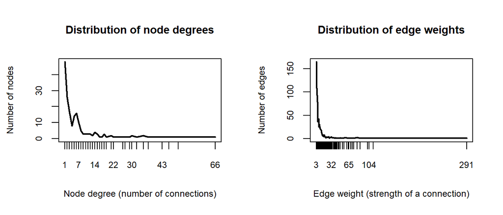

```r
par(mfrow=c(1,2))
plot(table(V(GoT)$degree), type="l", main = "Distribution of node degrees",
     cex.main = 0.9, xlab = "Node degree (number of connections)",
     ylab = "Number of nodes", cex.lab = 0.75, cex.axis = 0.75)
plot(table(E(GoT)$weight), type="l", main = "Distribution of edge weights",
     cex.main = 0.9, xlab = "Edge weight (strength of a connection)",
     ylab = "Number of edges", cex.lab = 0.75, cex.axis = 0.75)
```

Node degrees follow a power law distribution, which we can see on the plot above. Edge weight distribution performs the same on our data set.

If we subset a little part of our network object with square brackets, we can have a glimpse into our adjacency matrix showing weights of our edges (the number of times characters were co-mentioned):

```r
GoT[21:25,21:25]
```

```
## 5 x 5 sparse Matrix of class "dgCMatrix"
##                  Bronn Brynden Tully Catelyn Stark Cayn Cersei Lannister
## Bronn                .             .             6    .                .
## Brynden Tully        .             .            16    .                .
## Catelyn Stark        6            16             .    .               12
## Cayn                 .             .             .    .                .
## Cersei Lannister     .             .            12    .                .
```

## 5.3 Plotting a network

### 5.3.1 Static plots

Even though our network is not overly large, it’s larger than most toy networks used as examples in books and tutorials. Plotting a network even with around 200 nodes is not a trivial task. Edges and nodes may overlay each other, making a plot illegible and useless. Also, there is no single correct way to make a network plot, since the same data can be represented in a huge number of ways, and finding a layout that would make our plot an informative one is another challenge.

*“Although there are not in fact an inﬁnite number of ways to display a network on a screen, the number of possibilities might as well be. (For example, consider a moderate sized network of 50 nodes, and a display grid of 10 by 10. In actuality, the display grid would be much larger than this. The ﬁrst node in the network could be placed in any one of 100 positions, the 2nd node in 99 positions, and so on. In this example, there are 3.1×1093 different possible network layouts.) Most of the possibilities will produce ugly or confusing layouts, therefore there must be some way to pick a layout that has a better than average chance of being visually acceptable.”* (Luke (2015), p.47).

The author also specifies the guidelines of plotting network data:

- "*Minimize edge crossings.*
- *Maximize the symmetry of the layout of nodes.*
- *Minimize the variability of the edge lengths.*
- *Maximize the angle between edges when they cross or join nodes.*
- *Minimize the total space used for the network display.*"

Both `statnet` and `igraph` packages have a `plot()` function that can produce network plots, and the latter also has `plot.igraph()` function (equivalent to generic `plot()` function). Both packages have many capabilities to customize plots. We, however, won’t cover them here, as our network is too big for these generic functions. Plotting with the use of `statnet` library is covered in detail in Luke (2015) and examples of plotting with `igraph` package are given in Sadler (2017) and in the DataCamp course *Network Analysis in R*.

At the same time, the customization capabilities of the `ggraph` package are more substantial. It extends the power of `ggplot2`’s “grammar of graphics” to networks and allows the building of highly customized plots adding one element at a time. Knowledge of the `ggplot2` package comes in handy here, but if you never worked with this package, it might be tricky to build it from scratch. We’ll make our first plot of GoT network and then go through the code line by line.

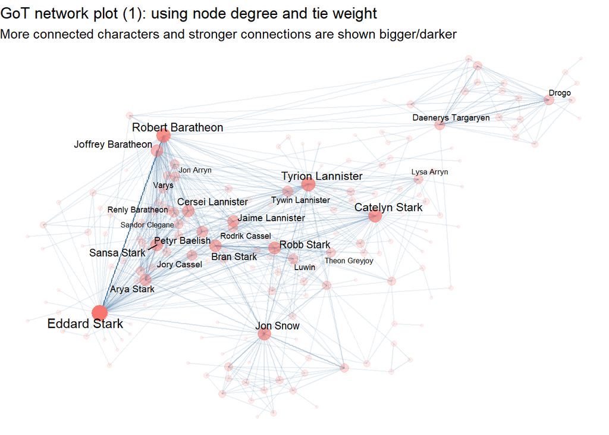

```r
set.seed(55555) # For reproducibility
ggraph(GoT, layout = "with_dh") +
  geom_edge_link(aes(alpha = weight, edge_colour = 1), show.legend = FALSE) +
  geom_node_point(aes(alpha = degree, size = degree, colour = "red"),
                  show.legend = FALSE) +
  geom_node_text(aes(label = name, filter = degree>=15, size=degree/3),
                 repel=TRUE, show.legend = FALSE) +
  labs(title = "GoT network plot (1): using node degree and tie weight",
       subtitle = "More connected characters and stronger connections are shown bigger/darker") +
  theme_void() # produces a plot similar to theme_graph()
```

By using `ggraph()` command, we signal our intention to build a plot and provide data (a graph object) for it. Within this command, we can also specify a graph layout with an argument `layout`. There exist many possible layouts for a network plot, and choosing one is rather an art than science. To explore the list of possible layouts, we can use the following command.

```r
ggraph:::igraphlayouts
```

```
##  [1] "as_bipartite"  "as_star"       "as_tree"       "in_circle"
##  [5] "nicely"        "with_dh"       "with_drl"      "with_gem"
##  [9] "with_graphopt" "on_grid"       "with_mds"      "with_sugiyama"
## [13] "on_sphere"     "randomly"      "with_fr"       "with_kk"
## [17] "with_lgl"
```

It is possible to read about each layout, for example,with `?layout_with_kk` in the console. All these layouts are described in the `igraph` package documentation, for example, in Csardi (2019).

The *force-directed* class of algorithms aims to place connected nodes closer on the graph while non-connected - apart from one another (Luke 2015). Examples of force-directed layout algorithms include:

- the Fruchterman-Reingold algorithm (`layout = "with_fr"`)
- the Kamada-Kawai algorithm (`layout = "with_kk"`)
- the Davidson-Harel algorithm (`layout = "with_dh"`)